# areaplot

#### Import modules

```python
import pandas as pd
import numpy as np
import seaborn as sns
import matplotlib as mpl
import matplotlib.pyplot as plt
%matplotlib inline
```

#### Reading in the table from .tsv

```python
df = pd.read_csv("family_metadata.tsv", delim_whitespace=True)
```

#### Printing columns and first 2 lines of the table

```python
df.head(2)
```

|  | sample-id | baby_id | family_id | gestational_age | group | sex | mode_delivery | Days_after_birth | Month_of_life | f__Methanobacteriaceae | ... | f__Xanthomonadaceae | f__Proteobacteria_unclassified | f__Spirochaetaceae | f__Synergistaceae | f__Mycoplasmataceae | f__Akkermansiaceae | f__Debaryomycetaceae | f__Saccharomycetaceae | f__Malasseziaceae | f__Cryptococcaceae |
| --- | --- | --- | --- | --- | --- | --- | --- | --- | --- | --- | --- | --- | --- | --- | --- | --- | --- | --- | --- | --- | --- |
| 0 | 2600164312 | 360 | 167 | 280 | Term | 1 | Vaginal | 0 | 0 | 0.0 | ... | 0.0 | 0.0 | 0.0 | 0.0 | 0.0 | 0.0 | 0.0 | 0.0 | 0.0 | 0.0 |
| 1 | 2600100341 | 162 | 69 | 278 | Term | 0 | Planned_C-section | 1 | 0 | 0.0 | ... | 0.0 | 0.0 | 0.0 | 0.0 | 0.0 | 0.0 | 0.0 | 0.0 | 0.0 | 0.0 |

2 rows × 111 columns

#### Printing index 0(vertical),0(horizontal) from df

```python
df.iloc[0,0]
```

```
2600164312
```

#### Traverse features

columns 9 -> end

#### Traverse samples

len(df["Days_after_birth"])

#### Get Y

for each feature if day == count, then, add feature value for that day to sum*. If day day != count then take average of sum* and append to feature_y. Also update count to new day. Finally, append feature_y to all_features_y, which is a matrix with the average value for each feature per day. Similar to df.GroupBy(["Days"]).mean().

#### Get unique X (pre sorted for days_after_birth)

for every value in column "Days_after_birth" if value != count then append value to x and update count to value. X already has 0 in beginning.

```python
all_features_y =[]
x = [0]

### Get Y values, takes the average rel abundance for per features across days_after_birth
for f in range(9, len(df.columns)):
    feature_y = []
    count = 0
    sum_ = []
    for m in range(0, len(df['Days_after_birth'])):
        if df.iloc[m,7] == count:
            sum_.append(df.iloc[m,f])
        else:
            feature_y.append(sum(sum_)/len(sum_))
            count = df.iloc[m,7]
            sum_ = [df.iloc[m,f]]
            if df.iloc[m,7] == 1452: #last number in col
                feature_y.append(sum(sum_)/len(sum_))
    all_features_y.append(feature_y)

### Get X values
count_x = 0
for m in range(0, len(df['Days_after_birth'])):
    if df.iloc[m,7] == count_x:
        count_x = df.iloc[m,7]
    else:
        x.append(df.iloc[m,7])
        count_x = df.iloc[m,7]
```

#### Create new df with x and all_features_y for each feature across days

```python
n_df = pd.DataFrame(all_features_y)
n_dfT = n_df.T
n_dfT.columns=df.columns[9:]
n_dfT.insert(0,"days",x,True)
n_dfT.head(3)
```

|  | days | f__Methanobacteriaceae | f__Actinomycetaceae | f__Bifidobacteriaceae | f__Candidatus_Nanopelagicaceae | f__Corynebacteriaceae | f__Corynebacteriales_unclassified | f__Mycobacteriaceae | f__Nocardiaceae | f__Dermabacteraceae | ... | f__Xanthomonadaceae | f__Proteobacteria_unclassified | f__Spirochaetaceae | f__Synergistaceae | f__Mycoplasmataceae | f__Akkermansiaceae | f__Debaryomycetaceae | f__Saccharomycetaceae | f__Malasseziaceae | f__Cryptococcaceae |
| --- | --- | --- | --- | --- | --- | --- | --- | --- | --- | --- | --- | --- | --- | --- | --- | --- | --- | --- | --- | --- | --- |
| 0 | 0 | 0.0 | 0.034890 | 1.621290 | 0.000000 | 0.000000 | 0.0 | 0.0 | 0.000000 | 0.000000 | ... | 0.000000 | 0.0 | 0.0 | 0.0 | 0.0 | 0.000000 | 0.000000 | 0.0 | 0.000000 | 0.0 |
| 1 | 1 | 0.0 | 0.847387 | 11.494797 | 0.000000 | 0.011447 | 0.0 | 0.0 | 0.000875 | 0.000168 | ... | 0.026757 | 0.0 | 0.0 | 0.0 | 0.0 | 0.315409 | 0.000481 | 0.0 | 0.116283 | 0.0 |
| 2 | 2 | 0.0 | 0.021098 | 11.556023 | 0.008037 | 0.066611 | 0.0 | 0.0 | 0.009440 | 0.000030 | ... | 0.038060 | 0.0 | 0.0 | 0.0 | 0.0 | 0.049007 | 0.031096 | 0.0 | 0.000002 | 0.0 |

3 rows × 103 columns

### Convert days to weeks and group by week

```python
### convert days to weeks
for f in range(0,len(n_dfT["days"])):
    n_dfT.iloc[f,0]=np.ceil(n_dfT.iloc[f,0]/7) ## divide by 7 and round up
    if n_dfT.iloc[f,0]==0: ## if 0 weeks make it 1
        n_dfT.iloc[f,0]=1

n_dfT.rename(columns={"days":"week"}, inplace=True)
n_dfT.head(10)

### Group all weeks by average
n_dfT_week = n_dfT.groupby(['week']).mean()
n_dfT_week.head(3)
```

| week | f__Methanobacteriaceae | f__Actinomycetaceae | f__Bifidobacteriaceae | f__Candidatus_Nanopelagicaceae | f__Corynebacteriaceae | f__Corynebacteriales_unclassified | f__Mycobacteriaceae | f__Nocardiaceae | f__Dermabacteraceae | f__Dermacoccaceae | ... | f__Xanthomonadaceae | f__Proteobacteria_unclassified | f__Spirochaetaceae | f__Synergistaceae | f__Mycoplasmataceae | f__Akkermansiaceae | f__Debaryomycetaceae | f__Saccharomycetaceae | f__Malasseziaceae | f__Cryptococcaceae |
| --- | --- | --- | --- | --- | --- | --- | --- | --- | --- | --- | --- | --- | --- | --- | --- | --- | --- | --- | --- | --- | --- |
| 1.0 | 0.0 | 0.140244 | 14.893356 | 0.001017 | 0.015392 | 0.005452 | 0.0 | 0.001466 | 0.000146 | 0.000139 | ... | 0.024454 | 0.000303 | 0.0 | 0.0 | 0.000039 | 0.155264 | 0.229836 | 0.0 | 0.015455 | 0.0 |
| 2.0 | 0.0 | 0.669317 | 3.637101 | 0.000000 | 0.002635 | 0.000000 | 0.0 | 0.000000 | 0.000000 | 0.000000 | ... | 0.000000 | 0.006080 | 0.0 | 0.0 | 0.000000 | 0.433487 | 0.000000 | 0.0 | 0.002133 | 0.0 |
| 3.0 | 0.0 | 0.017128 | 9.898849 | 0.000000 | 0.009322 | 0.000000 | 0.0 | 0.000000 | 0.002508 | 0.000870 | ... | 0.000106 | 0.000000 | 0.0 | 0.0 | 0.000000 | 2.163541 | 0.000000 | 0.0 | 0.000036 | 0.0 |

3 rows × 102 columns

### Set threshold (average across timepoints in specified range) and then rename features that did not meet to "other" and join by summing.

```python
### rename columns below 20% threshold for any day within first 104 timepoints to "other", keep others.
threshold=[]  ### features that met threshold
for f in range(0, len(n_dfT_week.columns)):
    tmp_avg = []
    for i in range(0,24): ## Timepoints (max 59 weeks)
        tmp_avg.append(n_dfT_week.iloc[i,f])
    if sum(tmp_avg)/len(tmp_avg) > 2:
        threshold.append(n_dfT_week.columns[f])

### renaming features below threshold to "other"
for f in range(0, len(n_dfT_week.columns)):
    cookies = [n_dfT_week.columns[f]]
    if bool(list(set(cookies).intersection(set(threshold))))==False:
        n_dfT_week.rename(columns={n_dfT_week.columns[f]:"other"}, inplace=True)

### combine all columns named "other" by sum
n_dfT_grouped = n_dfT_week.groupby(level=0, axis=1).sum()

print("features that met threshold:", threshold)
print("number of features that met threshold including \"other\" :", len(n_dfT_grouped.columns))
print("features that did not meet threshold were named \"other\" and grouped by sum")
```

```
features that met threshold: ['f__Bifidobacteriaceae', 'f__Bacteroidaceae', 'f__Staphylococcaceae', 'f__Enterococcaceae', 'f__Lachnospiraceae', 'f__Ruminococcaceae', 'f__Veillonellaceae', 'f__Enterobacteriaceae']
number of features that met threshold including "other" : 9
features that did not meet threshold were named "other" and grouped by sum
```

### Get Y values and labels for input into the plot. We will get a y_temp for each feature across all timepoints.

```python
### Get Y-values
y_=[]
for f in range(0, len(n_dfT_grouped.columns)):
    y_temp=[]
    for i in range (0,len(n_dfT_grouped)):
        y_temp.append(n_dfT_grouped.iloc[i,f])
    y_.append(y_temp)

### Get labels
labels_ =[]
for f in range(0, len(n_dfT_grouped.columns)):
    labels_.append(n_dfT_grouped.columns[f])

### timepoints
x_=["1","2","3","4","5","6","7","8","9","10","11","12","13","14","15","16","17","18","19","20","21","22","23","24","25","26","27","28","30","34","35","39","41","42","43","44","48","49","57","61","63","67","68","69","81","85","88","90","91","97","107","115","123","178","188","197","205","207","208"]
```

### Checkpoint

```python
print("total", len(x_), "timepoints")
print("total number of features including \"other\" is", len(y_))
print("each feature has data for", len(y_[0]),"timepoints")
print("sum of first row", sum(n_dfT_grouped.iloc[0]))
print("sum of second row",sum(n_dfT_grouped.iloc[1]))
print("sum of 59th row", sum(n_dfT_grouped.iloc[2]))
```

```
total 59 timepoints
total number of features including "other" is 9
each feature has data for 59 timepoints
sum of first row 99.99956524229916
sum of second row 99.99999937074831
sum of 59th row 100.00000125
```

#### Shortening each feature to only include data for the range we are interested in

```python
short_features = []
for f in y_:
    new_list = []
    for i in range(0,24): ### range of timepoints to shorten each feature by in this case, week.
        new_list.append(f[i])
    short_features.append(new_list)

print("number of features in short_features, this should inlcude \"other\":", len(short_features))
print("each feature has data for", len(short_features[0]),"timepoints")
```

```
number of features in short_features, this should inlcude "other": 9
each feature has data for 24 timepoints
```

### Plotting the figure

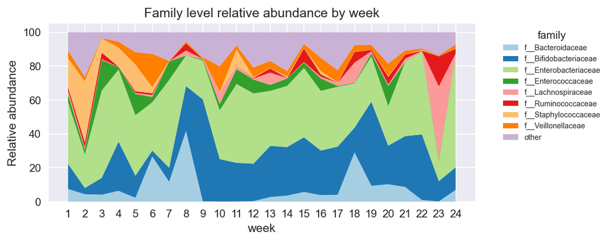

```python
# Basic stacked area chart.
mpl.style.use('seaborn')
fig,ax = plt.subplots(figsize=(7, 3), dpi=150)
col = sns.color_palette("Paired", 9)
ax.set_title("Family level relative abundance by week")
ax.set_ylabel('Relative abundance')
ax.set_xlabel("week")
fig = plt.stackplot(x_[:24], short_features, labels=labels_, colors=col)
plt.legend(title='family', bbox_to_anchor=(1.05, 1), loc='upper left', fontsize='x-small')
plt.savefig("relabundance_week.pdf", bbox_inches='tight')
#plt.show()
```

### Figure text

Mean relative abundance (RA) of gut microbes at family level across 24 weeks (6 months). Microbial families with RA <2% across the time period are labelled as "other".

### Metagenomics analyses

#### Quality filtering and host removal

347 and 60 demultiplexed fastq files from the Born-immune and IMPRINT cohort respectively were downstreams processed using the same pipeline and parameters. Demultiplexed samples were quality filtered using fastp v0.20.0 (https://doi.org/10.1093/bioinformatics/bty560), and host contamination removed using Kraken v2.0.8_beta (https://doi.org/10.1186/s13059-019-1891-0) by mapping against the NCBI's GRCh38.p13 database (https://www.ncbi.nlm.nih.gov/assembly/GCF_000001405.39). Both steps were run using default settings in StaG-mwc v.0.4.1 (https://doi.org/10.5281/zenodo.1483891).